# ARodriguez_ProjectFullCodeNB_EasyVisa

[figure not shown]

Data Science and Business Analytics

Ensemble Techniques and Model Tuning

[figure not shown]

Visa Approval Facilitation

# **Problem Statement**

## Context

Business communities in the United States are facing high demand for human resources, but one of the constant challenges is identifying and attracting the right talent, which is perhaps the most important element in remaining competitive. Companies in the United States look for hard-working, talented, and qualified individuals both locally as well as abroad.

The Immigration and Nationality Act (INA) of the US permits foreign workers to come to the United States to work on either a temporary or permanent basis. The act also protects US workers against adverse impacts on their wages or working conditions by ensuring US employers' compliance with statutory requirements when they hire foreign workers to fill workforce shortages. The immigration programs are administered by the Office of Foreign Labor Certification (OFLC).

OFLC processes job certification applications for employers seeking to bring foreign workers into the United States and grants certifications in those cases where employers can demonstrate that there are not sufficient US workers available to perform the work at wages that meet or exceed the wage paid for the occupation in the area of intended employment.

## Objective

In FY 2016, the OFLC processed 775,979 employer applications for 1,699,957 positions for temporary and permanent labor certifications. This was a nine percent increase in the overall number of processed applications from the previous year. The process of reviewing every case is becoming a tedious task as the number of applicants is increasing every year.

The increasing number of applicants every year calls for a Machine Learning based solution that can help in shortlisting the candidates having higher chances of VISA approval. OFLC has hired the firm EasyVisa for data-driven solutions. You as a data scientist at EasyVisa have to analyze the data provided and, with the help of a classification model:

- Facilitate the process of visa approvals.
- Recommend a suitable profile for the applicants for whom the visa should be certified or denied based on the drivers that significantly influence the case status.

## Data Description

The data contains the different attributes of employee and the employer. The detailed data dictionary is given below.

- case_id: ID of each visa application
- continent: Information of continent the employee
- education_of_employee: Information of education of the employee
- has_job_experience: Does the employee has any job experience? Y= Yes; N = No
- requires_job_training: Does the employee require any job training? Y = Yes; N = No
- no_of_employees: Number of employees in the employer's company
- yr_of_estab: Year in which the employer's company was established
- region_of_employment: Information of foreign worker's intended region of employment in the US.
- prevailing_wage: Average wage paid to similarly employed workers in a specific occupation in the area of intended employment. The purpose of the prevailing wage is to ensure that the foreign worker is not underpaid compared to other workers offering the same or similar service in the same area of employment.
- unit_of_wage: Unit of prevailing wage. Values include Hourly, Weekly, Monthly, and Yearly.
- full_time_position: Is the position of work full-time? Y = Full Time Position; N = Part Time Position
- case_status: Flag indicating if the Visa was certified or denied

## Note: This is a sample solution for the project. Projects will NOT be graded on the basis of how well the submission matches this sample solution. Projects will be graded on the basis of the rubric only.

# **Importing necessary libraries**

```python
# Installing the libraries with the specified version.
!pip install numpy==1.25.2 pandas==1.5.3 scikit-learn==1.2.2 matplotlib==3.7.1 seaborn==0.13.1 xgboost==2.0.3 -q --user
```

[output not shown]

**Note**: *After running the above cell, kindly restart the notebook kernel and run all cells sequentially from the start again.*

```python
# Libraries to help with reading and manipulating data
import pandas as pd
import numpy as np

# Libaries to help with data visualization
import matplotlib.pyplot as plt
import seaborn as sns

# To tune model, get different metric scores, and split data
from sklearn.metrics import (
    f1_score,
    accuracy_score,
    recall_score,
    precision_score,
    confusion_matrix,
    roc_auc_score,
    ConfusionMatrixDisplay,
)
from sklearn.model_selection import train_test_split, StratifiedKFold, cross_val_score

# To be used for data scaling and one hot encoding
from sklearn.preprocessing import StandardScaler, MinMaxScaler, OneHotEncoder

# To impute missing values
from sklearn.impute import SimpleImputer
from sklearn import metrics

# To oversample and undersample data
from imblearn.over_sampling import SMOTE
from imblearn.under_sampling import RandomUnderSampler

# To do hyperparameter tuning
from sklearn.model_selection import RandomizedSearchCV

# To define maximum number of columns to be displayed in a dataframe
pd.set_option("display.max_columns", None)

# To supress scientific notations for a dataframe
pd.set_option("display.float_format", lambda x: "%.3f" % x)

# To help with model building
from sklearn.tree import DecisionTreeClassifier
from sklearn.ensemble import (
    AdaBoostClassifier,
    GradientBoostingClassifier,
    RandomForestClassifier,
    BaggingClassifier,
)
from xgboost import XGBClassifier
from sklearn.linear_model import LogisticRegression

# To suppress scientific notations
pd.set_option("display.float_format", lambda x: "%.3f" % x)

# To supress warnings
import warnings

warnings.filterwarnings("ignore")
```

# **Loading the dataset**

```python
# Accessing folder from google.colab drive
from google.colab import drive
drive.mount('/content/drive/')

# Opening csv data file
df = pd.read_csv('/content/drive/MyDrive/Ensemble/EasyVisa.csv')
```

```python
# Creating a copy of original dataset
data = df.copy()
```

# **Overview of the Dataset**

- Observations
- Sanity checks

```python
# Checking first 5 rows of dataset
data.head()
```

|  | case_id | continent | education_of_employee | has_job_experience | requires_job_training | no_of_employees | yr_of_estab | region_of_employment | prevailing_wage | unit_of_wage | full_time_position | case_status |
| --- | --- | --- | --- | --- | --- | --- | --- | --- | --- | --- | --- | --- |
| 0 | EZYV01 | Asia | High School | N | N | 14513 | 2007 | West | 592.203 | Hour | Y | Denied |
| 1 | EZYV02 | Asia | Master's | Y | N | 2412 | 2002 | Northeast | 83425.650 | Year | Y | Certified |
| 2 | EZYV03 | Asia | Bachelor's | N | Y | 44444 | 2008 | West | 122996.860 | Year | Y | Denied |
| 3 | EZYV04 | Asia | Bachelor's | N | N | 98 | 1897 | West | 83434.030 | Year | Y | Denied |
| 4 | EZYV05 | Africa | Master's | Y | N | 1082 | 2005 | South | 149907.390 | Year | Y | Certified |

```python
# Checking last 5 rows of dataset
data.tail()
```

|  | case_id | continent | education_of_employee | has_job_experience | requires_job_training | no_of_employees | yr_of_estab | region_of_employment | prevailing_wage | unit_of_wage | full_time_position | case_status |
| --- | --- | --- | --- | --- | --- | --- | --- | --- | --- | --- | --- | --- |
| 25475 | EZYV25476 | Asia | Bachelor's | Y | Y | 2601 | 2008 | South | 77092.570 | Year | Y | Certified |
| 25476 | EZYV25477 | Asia | High School | Y | N | 3274 | 2006 | Northeast | 279174.790 | Year | Y | Certified |
| 25477 | EZYV25478 | Asia | Master's | Y | N | 1121 | 1910 | South | 146298.850 | Year | N | Certified |
| 25478 | EZYV25479 | Asia | Master's | Y | Y | 1918 | 1887 | West | 86154.770 | Year | Y | Certified |
| 25479 | EZYV25480 | Asia | Bachelor's | Y | N | 3195 | 1960 | Midwest | 70876.910 | Year | Y | Certified |

```python
# Checking shape of dataset
print("There are", data.shape[0], "rows and", data.shape[1], "columns in the dataset.")
```

```
There are 25480 rows and 12 columns in the dataset.
```

```python
# Checking the data types of columns in dataset
data.info()
```

```
<class 'pandas.core.frame.DataFrame'>
RangeIndex: 25480 entries, 0 to 25479
Data columns (total 12 columns):
 #   Column                 Non-Null Count  Dtype
---  ------                 --------------  -----
 0   case_id                25480 non-null  object
 1   continent              25480 non-null  object
 2   education_of_employee  25480 non-null  object
 3   has_job_experience     25480 non-null  object
 4   requires_job_training  25480 non-null  object
 5   no_of_employees        25480 non-null  int64
 6   yr_of_estab            25480 non-null  int64
 7   region_of_employment   25480 non-null  object
 8   prevailing_wage        25480 non-null  float64
 9   unit_of_wage           25480 non-null  object
 10  full_time_position     25480 non-null  object
 11  case_status            25480 non-null  object
dtypes: float64(1), int64(2), object(9)
memory usage: 2.3+ MB
```

```python
# Checking for missing values in the data
data.isnull().sum()
```

|  | 0 |
| --- | --- |
| case_id | 0 |
| continent | 0 |
| education_of_employee | 0 |
| has_job_experience | 0 |
| requires_job_training | 0 |
| no_of_employees | 0 |
| yr_of_estab | 0 |
| region_of_employment | 0 |
| prevailing_wage | 0 |
| unit_of_wage | 0 |
| full_time_position | 0 |
| case_status | 0 |

**dtype:** int64

- There are no missing values in the dataset.

```python
# Checking for duplicates
data.duplicated().sum()
```

```
np.int64(0)
```

- There are no duplicates in the dataset.

```python
# Getting a statistical summary
data.describe().T
```

|  | count | mean | std | min | 25% | 50% | 75% | max |
| --- | --- | --- | --- | --- | --- | --- | --- | --- |
| no_of_employees | 25480.000 | 5667.043 | 22877.929 | -26.000 | 1022.000 | 2109.000 | 3504.000 | 602069.000 |
| yr_of_estab | 25480.000 | 1979.410 | 42.367 | 1800.000 | 1976.000 | 1997.000 | 2005.000 | 2016.000 |
| prevailing_wage | 25480.000 | 74455.815 | 52815.942 | 2.137 | 34015.480 | 70308.210 | 107735.513 | 319210.270 |

**Converting `prevailing_wage` into annual amounts for comparability**

```python
# Creating a conversion dictionary
conversion = {
    'Hour': 40 * 52,   # 40 hours * 52 weeks
    'Week': 52,
    'Month': 12,
    'Year': 1
}
# Converting all wage types to annual
data['annual_wage'] = data['prevailing_wage'] * data['unit_of_wage'].map(conversion)

# Updating prevailing_wage column
data['prevailing_wage'] = data['annual_wage']
data = data.drop(columns=['annual_wage'])
```

```python
data.describe().T
```

|  | count | mean | std | min | 25% | 50% | 75% | max |
| --- | --- | --- | --- | --- | --- | --- | --- | --- |
| no_of_employees | 25480.000 | 5667.043 | 22877.929 | -26.000 | 1022.000 | 2109.000 | 3504.000 | 602069.000 |
| yr_of_estab | 25480.000 | 1979.410 | 42.367 | 1800.000 | 1976.000 | 1997.000 | 2005.000 | 2016.000 |
| prevailing_wage | 25480.000 | 197391.155 | 578591.666 | 100.000 | 47107.965 | 82839.460 | 124825.035 | 14569149.400 |

- Because the 25th percentile and min and the 75th percentile and max have huge gaps, there will be outliers on the upper and lower ends for `prevailing_wage`.

```python
# Dropping case_id because it has no predictive power
data = data.drop(columns=['case_id'])
```

```python
# Getting counts for categorical variables
cat_cols = data.select_dtypes(include='object').columns

for col in cat_cols:
    print(f"\n---------- {col} ----------")
    print(data[col].value_counts(dropna=False))
```

```
---------- continent ----------
continent
Asia             16861
Europe            3732
North America     3292
South America      852
Africa             551
Oceania            192
Name: count, dtype: int64

---------- education_of_employee ----------
education_of_employee
Bachelor's     10234
Master's        9634
High School     3420
Doctorate       2192
Name: count, dtype: int64

---------- has_job_experience ----------
has_job_experience
Y    14802
N    10678
Name: count, dtype: int64

---------- requires_job_training ----------
requires_job_training
N    22525
Y     2955
Name: count, dtype: int64

---------- region_of_employment ----------
region_of_employment
Northeast    7195
South        7017
West         6586
Midwest      4307
Island        375
Name: count, dtype: int64

---------- unit_of_wage ----------
unit_of_wage
Year     22962
Hour      2157
Week       272
Month       89
Name: count, dtype: int64

---------- full_time_position ----------
full_time_position
Y    22773
N     2707
Name: count, dtype: int64

---------- case_status ----------
case_status
Certified    17018
Denied        8462
Name: count, dtype: int64
```

```python
# Getting counts in percentage
cat_cols = data.select_dtypes(include=['object', 'category']).columns

for col in cat_cols:
    print(f"\n---------- {col} ----------")
    print((data[col].value_counts(normalize=True, dropna=False) * 100).round(2))
```

```
---------- continent ----------
continent
Asia            66.170
Europe          14.650
North America   12.920
South America    3.340
Africa           2.160
Oceania          0.750
Name: proportion, dtype: float64

---------- education_of_employee ----------
education_of_employee
Bachelor's    40.160
Master's      37.810
High School   13.420
Doctorate      8.600
Name: proportion, dtype: float64

---------- has_job_experience ----------
has_job_experience
Y   58.090
N   41.910
Name: proportion, dtype: float64

---------- requires_job_training ----------
requires_job_training
N   88.400
Y   11.600
Name: proportion, dtype: float64

---------- region_of_employment ----------
region_of_employment
Northeast   28.240
South       27.540
West        25.850
Midwest     16.900
Island       1.470
Name: proportion, dtype: float64

---------- unit_of_wage ----------
unit_of_wage
Year    90.120
Hour     8.470
Week     1.070
Month    0.350
Name: proportion, dtype: float64

---------- full_time_position ----------
full_time_position
Y   89.380
N   10.620
Name: proportion, dtype: float64

---------- case_status ----------
case_status
Certified   66.790
Denied      33.210
Name: proportion, dtype: float64
```

# **Exploratory Data Analysis (EDA)**

- EDA is an important part of any project involving data.
- It is important to investigate and understand the data better before building a model with it.
- A few questions have been mentioned below which will help you approach the analysis in the right manner and generate insights from the data.
- A thorough analysis of the data, in addition to the questions mentioned below, should be done.

# **Leading Questions**

**1. What is the distribution of visa case statuses (certified vs. denied)?**

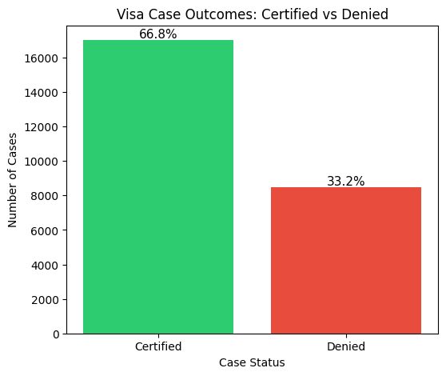

```python
# Count certified vs denied
case_counts = data['case_status'].value_counts()
labels = case_counts.index
values = case_counts.values
colors = ['#2ecc71', '#e74c3c']  # green / red

plt.figure(figsize=(6,5))
bars = plt.bar(labels, values, color=colors)

# Add percentage labels
total = values.sum()
for bar in bars:
    height = bar.get_height()
    percentage = f"{100 * height / total:.1f}%"
    plt.text(
        bar.get_x() + bar.get_width()/2,
        height,
        percentage,
        ha='center', va='bottom', fontsize=11
    )

plt.xlabel("Case Status")
plt.ylabel("Number of Cases")
plt.title("Visa Case Outcomes: Certified vs Denied")
plt.show()
```

- About 67% of the cases were certified and about 33% were denied.

**2. How does the education level of employees impact visa approval rates?**

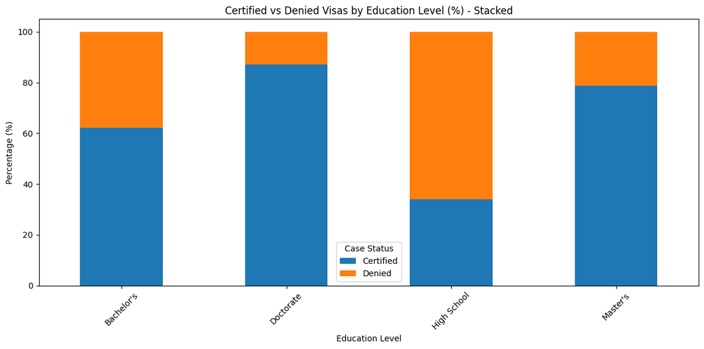

```python
edu_status_counts = data.groupby(['education_of_employee', 'case_status']).size().unstack(fill_value=0)
edu_status_pct = edu_status_counts.div(edu_status_counts.sum(axis=1), axis=0) * 100

edu_status_pct.plot(kind='bar', stacked=True, figsize=(12, 6))

plt.title('Certified vs Denied Visas by Education Level (%) - Stacked')
plt.xlabel('Education Level')
plt.ylabel('Percentage (%)')
plt.xticks(rotation=45)
plt.legend(title='Case Status')
plt.tight_layout()
plt.show()
```

- Employees with Doctorates had the greatest percentage of approved Visas at about 90%, followed by Master's at ~80%, Bachelor's at ~60%, and Highschool with the least percentage of approved Visas at less than 40%.

**3. Is there a significant difference in visa approval rates between employees with and without prior job experience?**

```python
# Creating a table for visa approval by job experience
job_exp_counts = data.groupby(['has_job_experience', 'case_status']).size().unstack(fill_value=0)
job_exp_counts
```

| case_status has_job_experience | Certified | Denied |
| --- | --- | --- |
| N | 5994 | 4684 |
| Y | 11024 | 3778 |

```python
# Converting the counts to percentage
job_exp_pct = job_exp_counts.div(job_exp_counts.sum(axis=1), axis=0) * 100
job_exp_pct
```

| case_status has_job_experience | Certified | Denied |
| --- | --- | --- |
| N | 56.134 | 43.866 |
| Y | 74.476 | 25.524 |

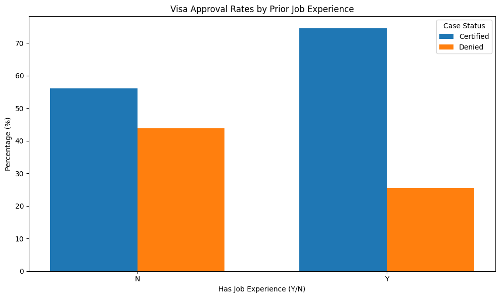

```python
# Creating a barplot for visa approval by job experience
order = job_exp_pct.index.tolist()
x = np.arange(len(order))
width = 0.35

plt.figure(figsize=(10,6))

certified = plt.bar(
    x - width/2,
    job_exp_pct.loc[order, 'Certified'],
    width,
    label='Certified'
)

denied = plt.bar(
    x + width/2,
    job_exp_pct.loc[order, 'Denied'],
    width,
    label='Denied'
)

plt.xticks(x, order)
plt.xlabel("Has Job Experience (Y/N)")
plt.ylabel("Percentage (%)")
plt.title("Visa Approval Rates by Prior Job Experience")
plt.legend(title="Case Status")

plt.tight_layout()
plt.show()
```

- There is a marked difference in visa approval between those who did and did not have previous work experience.
- 74% of employees that had experience were approved while just 56% of employees without experience were approved.

**4. How does the prevailing wage affect visa approval? Do higher wages lead to higher chances of approval?**

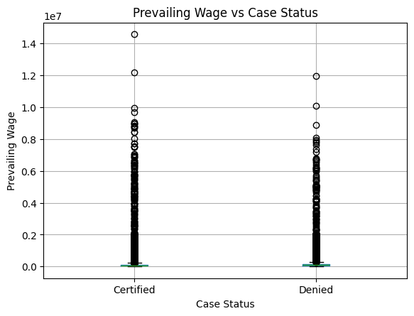

```python
# Showing boxplot of wage vs. case status
plt.figure(figsize=(10,6))
data.boxplot(column='prevailing_wage', by='case_status')
plt.title("Prevailing Wage vs Case Status")
plt.suptitle("")
plt.xlabel("Case Status")
plt.ylabel("Prevailing Wage")
plt.show()
```

- This visualization is highly skewed from the many extreme outliers and not effective for interpretation. Breaking the wages into bins will make it more effective.

```python
# Creating bins based on quartiles
data['wage_bin'] = pd.qcut(
    data['prevailing_wage'],
    q=4,
    labels=['Low', 'Medium', 'High', 'Very High']
)
```

```python
# Calculating approval rates within each bin
wage_status_counts = data.groupby(['wage_bin', 'case_status']).size().unstack(fill_value=0)
wage_status_pct = wage_status_counts.div(wage_status_counts.sum(axis=1), axis=0) * 100
wage_status_pct
```

| case_status wage_bin | Certified | Denied |
| --- | --- | --- |
| Low | 71.162 | 28.838 |
| Medium | 69.639 | 30.361 |
| High | 68.477 | 31.523 |
| Very High | 57.881 | 42.119 |

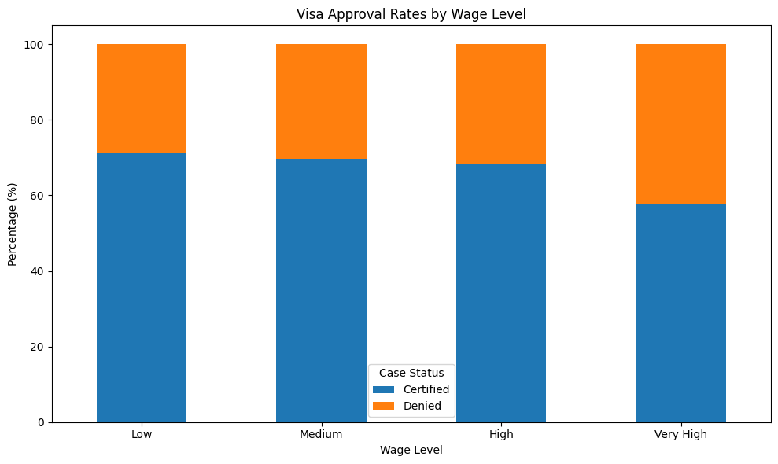

```python
# Making a stacked barplot of Cases status by Wage level
wage_status_pct.plot(
    kind='bar',
    stacked=True,
    figsize=(10,6)
)

plt.title("Visa Approval Rates by Wage Level")
plt.xlabel("Wage Level")
plt.ylabel("Percentage (%)")
plt.legend(title="Case Status")
plt.xticks(rotation=0)
plt.tight_layout()
plt.show()
```

- The first three quartile bins of wages (Low, Medium and High) have the higher approval rates close to 70% while the approval rates for Very High prevailing wage is about 60%. It does appear to be a factor in Visa approval.

**5. Do certain regions in the US have higher visa approval rates compared to others?**

```python
# Getting counts of visa approval by region
region_counts = data.groupby(['region_of_employment', 'case_status']).size().unstack(fill_value=0)
region_counts
```

| case_status region_of_employment | Certified | Denied |
| --- | --- | --- |
| Island | 226 | 149 |
| Midwest | 3253 | 1054 |
| Northeast | 4526 | 2669 |
| South | 4913 | 2104 |
| West | 4100 | 2486 |

```python
# Converting counts to percentages
region_pct = region_counts.div(region_counts.sum(axis=1), axis=0) * 100
region_pct
```

| case_status region_of_employment | Certified | Denied |
| --- | --- | --- |
| Island | 60.267 | 39.733 |
| Midwest | 75.528 | 24.472 |
| Northeast | 62.905 | 37.095 |
| South | 70.016 | 29.984 |
| West | 62.253 | 37.747 |

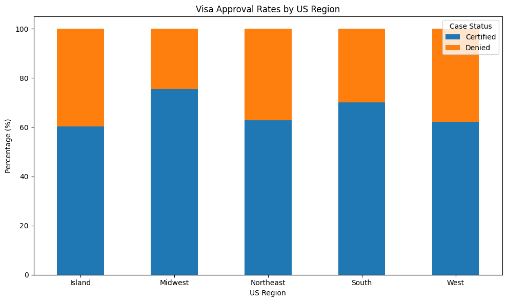

```python
# Making a stacked barplot of Case status by Region
region_pct.plot(
    kind='bar',
    stacked=True,
    figsize=(10,6)
)

plt.title("Visa Approval Rates by US Region")
plt.xlabel("US Region")
plt.ylabel("Percentage (%)")
plt.legend(title="Case Status")
plt.xticks(rotation=0)
plt.tight_layout()
plt.show()
```

- The region with the highest percentage of Visa approvals was Midwest with 75%.
- The South had the second highest Visa approval at 70%.
- Island had the least amount of Visa approvals at about 60%.
- The West and Northeast had similarly low Visa Approvals at about 62% each.

**6. How does the number of employees in a company influence visa approval? Do larger companies have a higher approval rate?**

```python
# Creating company size buckets based on quartiles
bins = [0, 1022, 2109, 3504, float('inf')]
labels = ['Small', 'Medium', 'Large', 'Very Large']

data['company_size'] = pd.cut(
    data['no_of_employees'],
    bins=bins,
    labels=labels,
    include_lowest=True
)
```

```python
# Computing approval percentages
size_counts = data.groupby(['company_size', 'case_status']).size().unstack(fill_value=0)
size_pct = size_counts.div(size_counts.sum(axis=1), axis=0) * 100
size_pct
```

| case_status company_size | Certified | Denied |
| --- | --- | --- |
| Small | 65.994 | 34.006 |
| Medium | 65.609 | 34.391 |
| Large | 66.039 | 33.961 |
| Very Large | 69.593 | 30.407 |

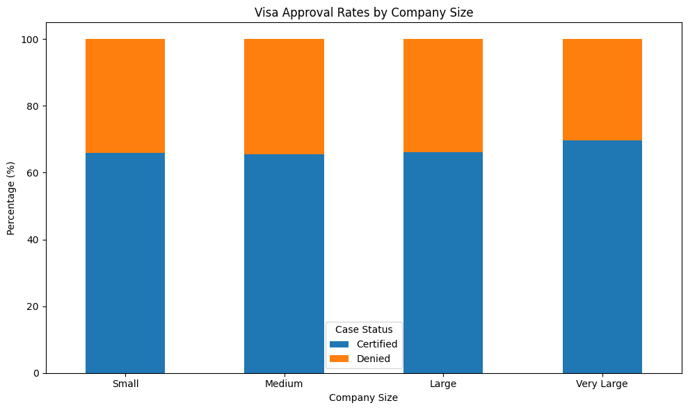

```python
# Making a stacked barplot of Cases status by Wage level
size_pct.plot(
    kind='bar',
    stacked=True,
    figsize=(10,6)
)

plt.title("Visa Approval Rates by Company Size")
plt.xlabel("Company Size")
plt.ylabel("Percentage (%)")
plt.legend(title="Case Status")
plt.xticks(rotation=0)
plt.tight_layout()
plt.show()
```

- The largest gap in approval rate was between very large at ~69% and Medium at ~65%. This implies that larger companies have a higher approval rate, but not by much.

**7. Are visa approval rates different across various continents of employees? Which continent has the highest and lowest approval rates?**

```python
# Getting counts of Visa approval by continent
continent_counts = data.groupby(['continent', 'case_status']).size().unstack(fill_value=0)
continent_counts
```

| case_status continent | Certified | Denied |
| --- | --- | --- |
| Africa | 397 | 154 |
| Asia | 11012 | 5849 |
| Europe | 2957 | 775 |
| North America | 2037 | 1255 |
| Oceania | 122 | 70 |
| South America | 493 | 359 |

```python
# Converting counts into percentages
continent_pct = continent_counts.div(continent_counts.sum(axis=1), axis=0) * 100
continent_pct
```

| case_status continent | Certified | Denied |
| --- | --- | --- |
| Africa | 72.051 | 27.949 |
| Asia | 65.310 | 34.690 |
| Europe | 79.234 | 20.766 |
| North America | 61.877 | 38.123 |
| Oceania | 63.542 | 36.458 |
| South America | 57.864 | 42.136 |

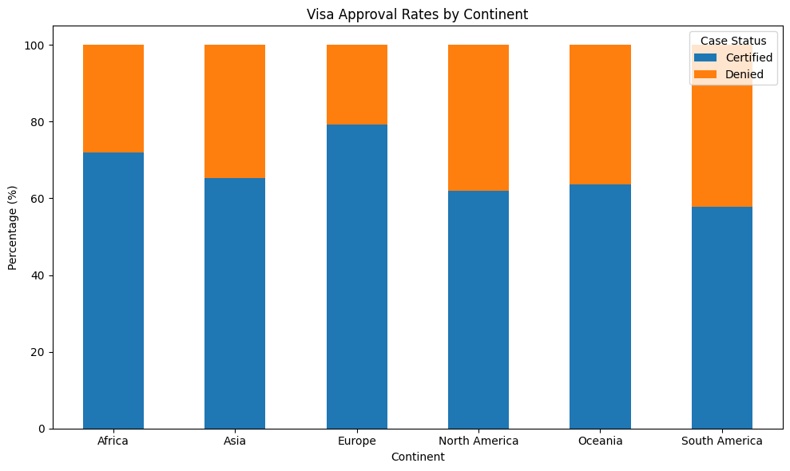

```python
# Making a stacked barplot of Cases status by Wage level
continent_pct.plot(
    kind='bar',
    stacked=True,
    figsize=(10,6)
)

plt.title("Visa Approval Rates by Continent")
plt.xlabel("Continent")
plt.ylabel("Percentage (%)")
plt.legend(title="Case Status")
plt.xticks(rotation=0)
plt.tight_layout()
plt.show()
```

- The Visa approval rates across continents vary widely from almost 80% to a low of about 57%.
- The leading continents with the highest approval rate is Europe at 79%, Africa at 72%, and Asia at 65%.
- The continents with the lowest approval rate are Oceania at 63%, North America at 61%, and South America at 57%.